# MODELO PARA LA PENDIENTE (m) DEL CONSUMO DE ACIDO

2022-03-12

## OBJETIVO

El trabajo consistió en modelar la pendiente del modelo fenomenológico de consumo de ácido con diferentes propiedades medibles del mineral, en base a los datos generados en los ensayos de laboratorio realizados en minicolumnas.

## INTRODUCCION

Modelo cinético inicial propuesto:

CHN = (A0)x(1-(1-r0)^t) + (A1)x(1-(1-r1)^t) + (A2)x(1-(1-r2)^t)

En donde:

- CHN = Consumo ácido neto [kg/t].
- A = máximo consumo de ácido en [kg/t], según la etapa.
- r = tasa de consumo de ácido en [kg/t/d] para cada “A”, según su etapa.
- t = tiempo de lixiviación en días.

En donde las etapas del proceso son: 0: “curado”, 1: primer drenaje, 2: tiempo infinito.

Con la siguiente información conocida:

- A0 = ácido en etapa de “curado”, menos 1.54 x CuT x 10 x %CuTSulfatado [kg/t]
- A1 = 0
- A2 = máximo consumo; 200 [kg/t], menos A0
- r0 = 0.9
- r1 = 0
- r2 = velocidad o pendiente m etapa 2, a modelar en base a información de lixiviación en minicolumnas.

## ANALISIS DE CORRELACIONES

|  | Variables |
| --- | --- |
| 1 | ch_fe_co3_kgt |
| 2 | cu_ssec_pct |
| 3 | fe_t_pct |
| 4 | co3_pct |
| 5 | ca_at_kgt |
| 6 | ca_ag_kgt |
| 7 | ch_giso_kgt |
| 8 | cu_t_pct |
| 9 | mn_t_pct |
| 10 | cl_pct |

[output cut: 16 more lines]

### Gráfica de Correlación por Método Pearson

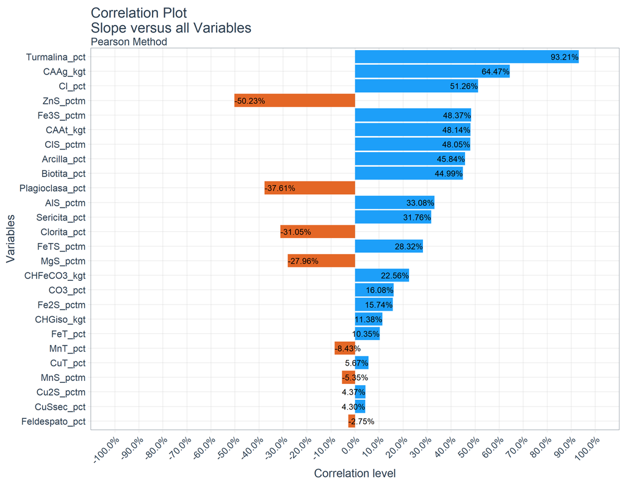

### Gráficas de Dispersión Lineal

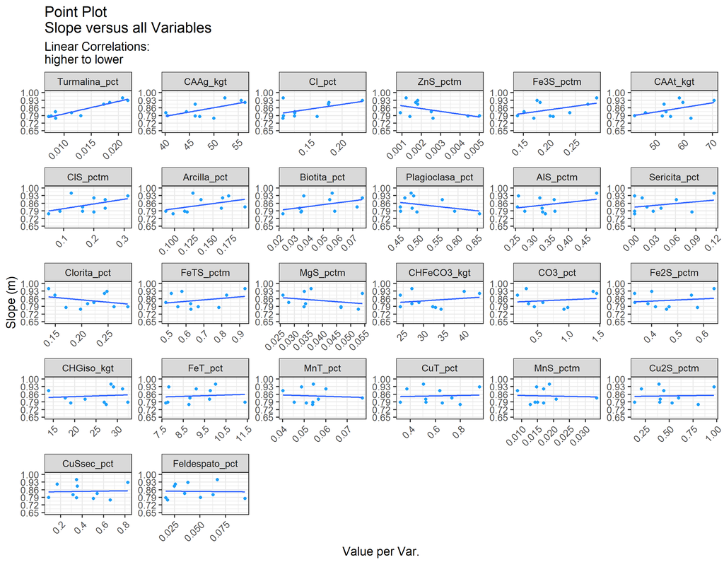

## MODELACION

A continuación se presentan diferentes modelos para la pendiente (m) del consumo de ácido neto (CHN/CHG).

### Modelo en base a Turmalina (SLR)

```
  (Intercept) Turmalina_pct
    0.6932381    11.3530304
```

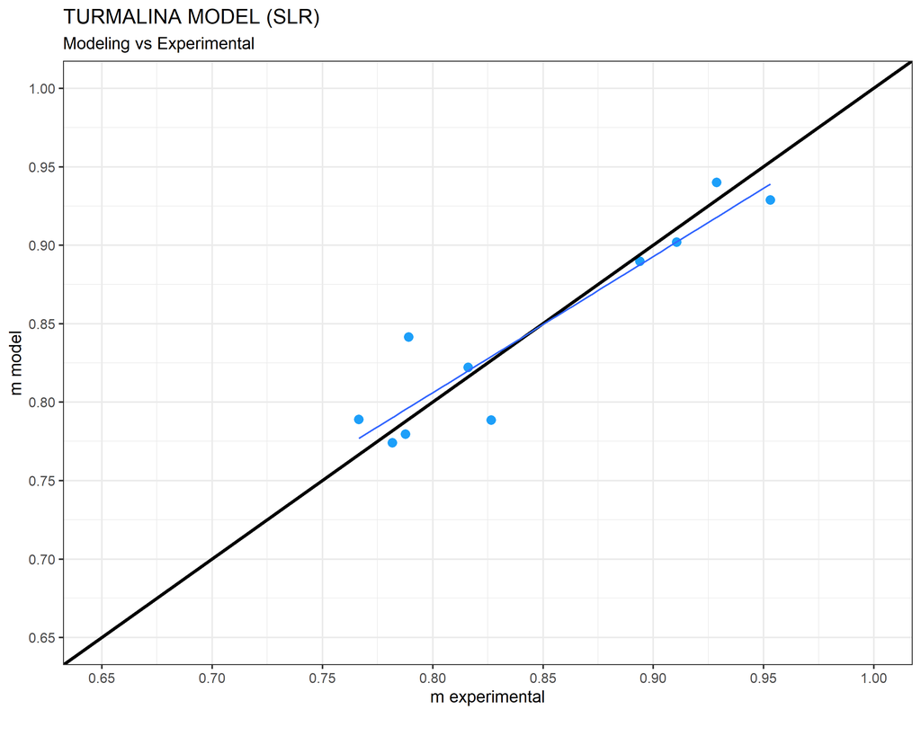

### Modelo Regularizado (RIDGE)

Este modelo considera todas las variables con regularización **RIDGE**, la cual regulariza (contrae hacia cero) los coeficientes de las variables que tienen un menor efecto en la respuesta.

```
[1] 0.6122353
```

```
27 x 1 sparse Matrix of class "dgCMatrix"
                           s0
(Intercept)      0.7456725824
CHFeCO3_kgt      0.0001572316
CuSsec_pct       0.0001107238
FeT_pct          0.0006422169
CO3_pct          0.0013723308
CAAt_kgt         0.0003073819
CAAg_kgt         0.0005977381
CHGiso_kgt       0.0001469839
CuT_pct          0.0005111523
MnT_pct         -0.0324004526
Cl_pct           0.0601056665
Arcilla_pct      0.0704535536
Clorita_pct     -0.0277819260
Biotita_pct      0.1444635130
Plagioclasa_pct -0.0288921553
Feldespato_pct  -0.0220240882
Sericita_pct     0.0369423716
Turmalina_pct    0.8882033280
Cu2S_pctm        0.0001990048
FeTS_pctm        0.0094826893
Fe2S_pctm        0.0065670739
Fe3S_pctm        0.0492908598
AlS_pctm         0.0284460835
MgS_pctm        -0.1572943148
MnS_pctm        -0.0314788700
ZnS_pctm        -1.6797977526
ClS_pctm         0.0296622620
```

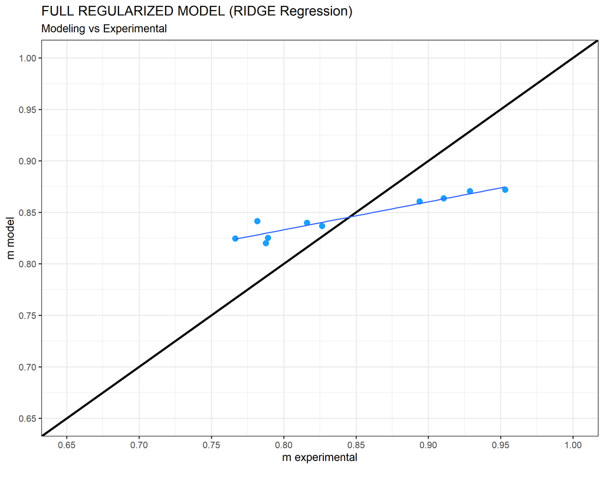

### Modelo Regularizado (LASSO)

Este modelo considera todas las variables con regularización **LASSO**, la cual hace cero los coeficientes de las variables que tienen un menor efecto en la respuesta.

```
[1] 0.03503436
```

```
27 x 1 sparse Matrix of class "dgCMatrix"
                       s0
(Intercept)     0.7803451
CHFeCO3_kgt     .
CuSsec_pct      .
FeT_pct         .
CO3_pct         .
CAAt_kgt        .
CAAg_kgt        .
CHGiso_kgt      .
CuT_pct         .
MnT_pct         .
Cl_pct          .
Arcilla_pct     .
Clorita_pct     .
Biotita_pct     .
Plagioclasa_pct .
Feldespato_pct  .
Sericita_pct    .
Turmalina_pct   4.8564090
Cu2S_pctm       .
FeTS_pctm       .
Fe2S_pctm       .
Fe3S_pctm       .
AlS_pctm        .
MgS_pctm        .
MnS_pctm        .
ZnS_pctm        .
ClS_pctm        .
```

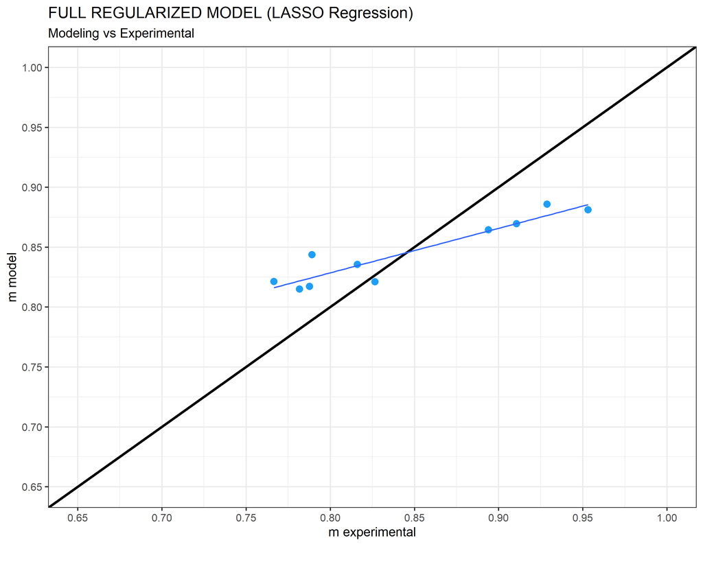

### Modelo Corr >40% (MLR)

```
    (Intercept)   Turmalina_pct     Biotita_pct        CAAg_kgt       Fe3S_pctm
     0.52484992      6.44060433      0.77322730      0.00379180      0.58064344
Plagioclasa_pct        AlS_pctm
    -0.09125746     -0.16852404
```

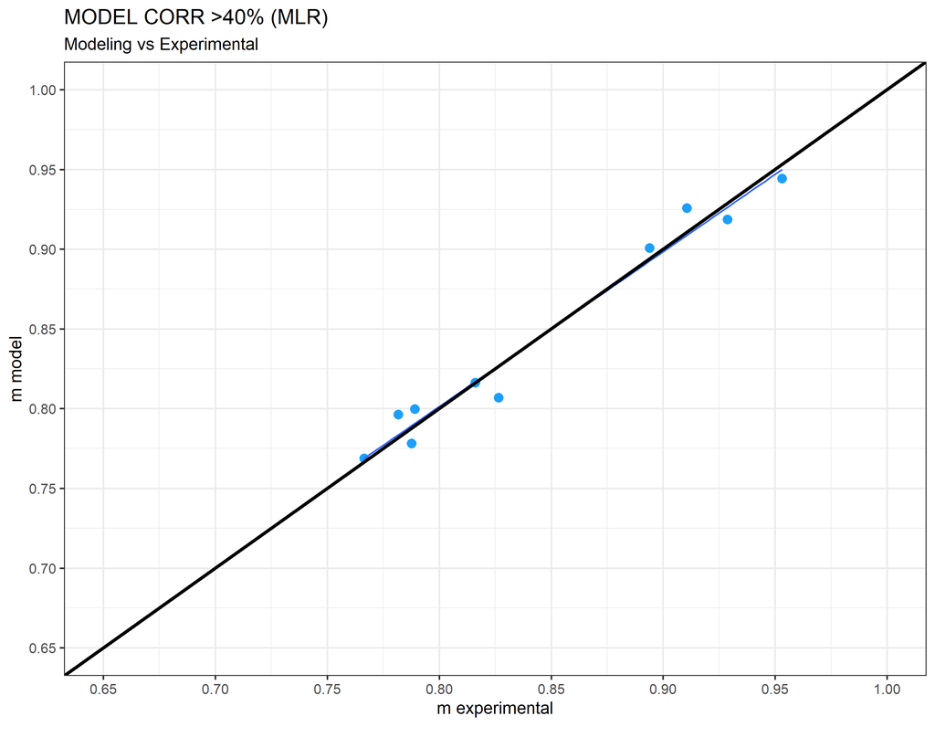

### Modelo Corr >40% Testeo (MLR)

```
 (Intercept)     CAAg_kgt    Fe3S_pctm     AlS_pctm
 0.389434061  0.008176235  1.101460390 -0.482203157
```

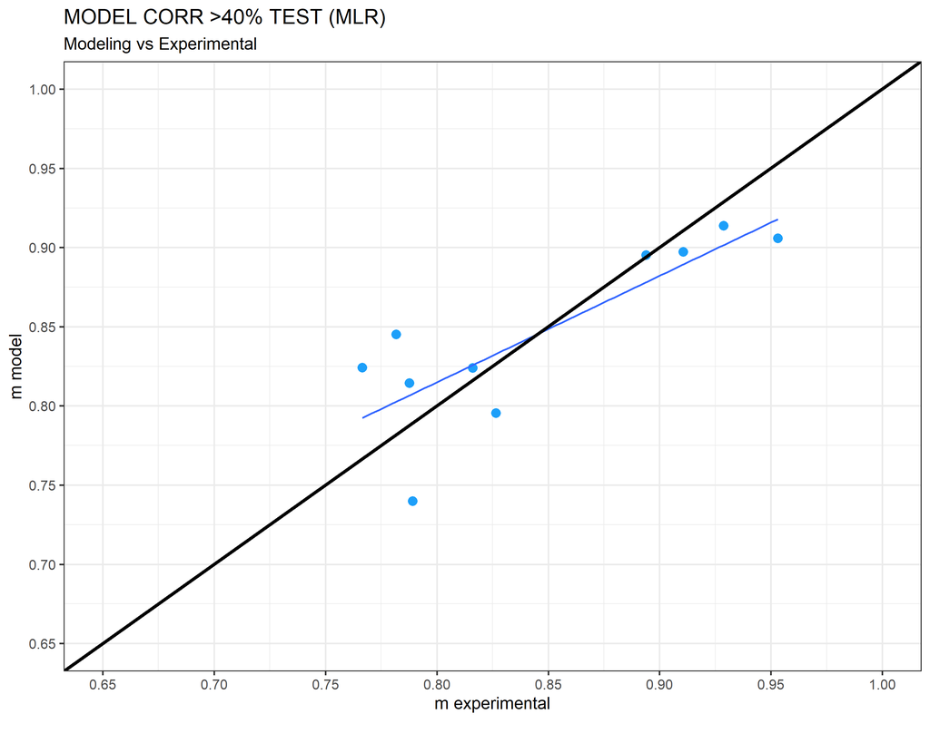

### Modelo Corr >40% Testeo (RIDGE)

```
[1] 0.03598469
```

```
4 x 1 sparse Matrix of class "dgCMatrix"
                    s0
(Intercept) 0.52641968
CAAg_kgt    0.00490438
Fe3S_pctm   0.38994243
AlS_pctm    0.01592228
```

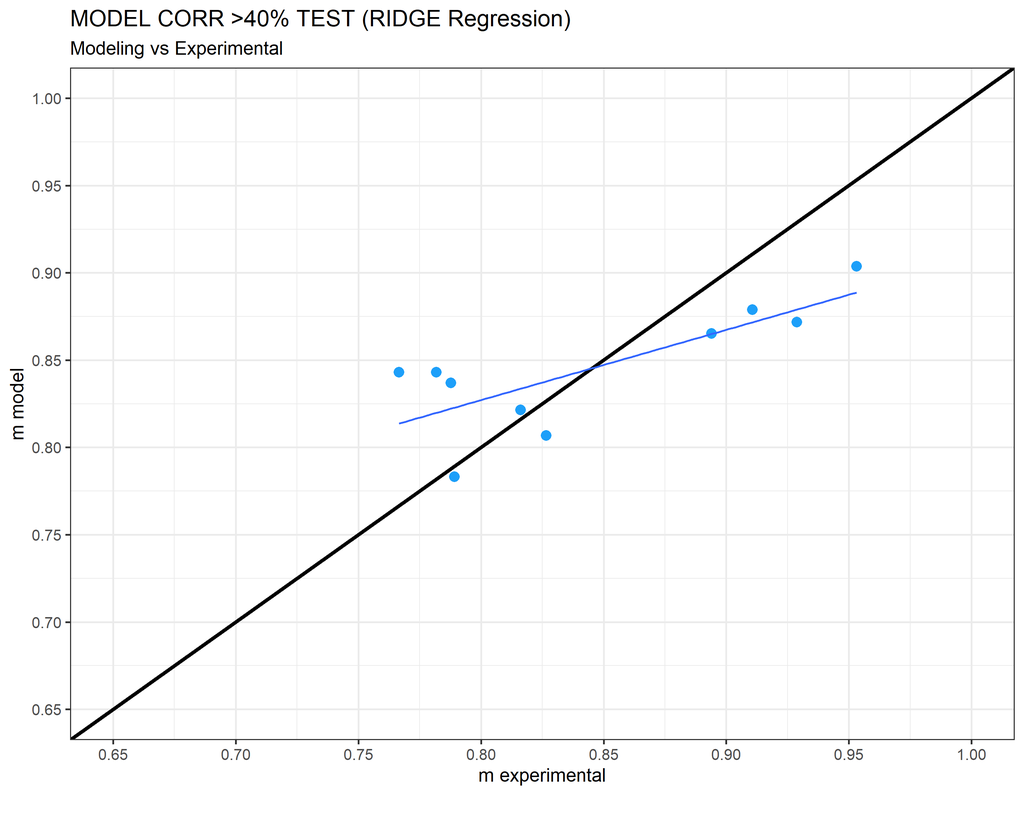

### Modelo Corr >40% Testeo (LASSO)

```
[1] 0.0138668
```

```
4 x 1 sparse Matrix of class "dgCMatrix"
                     s0
(Intercept) 0.535009783
CAAg_kgt    0.005083752
Fe3S_pctm   0.331120276
AlS_pctm    .
```

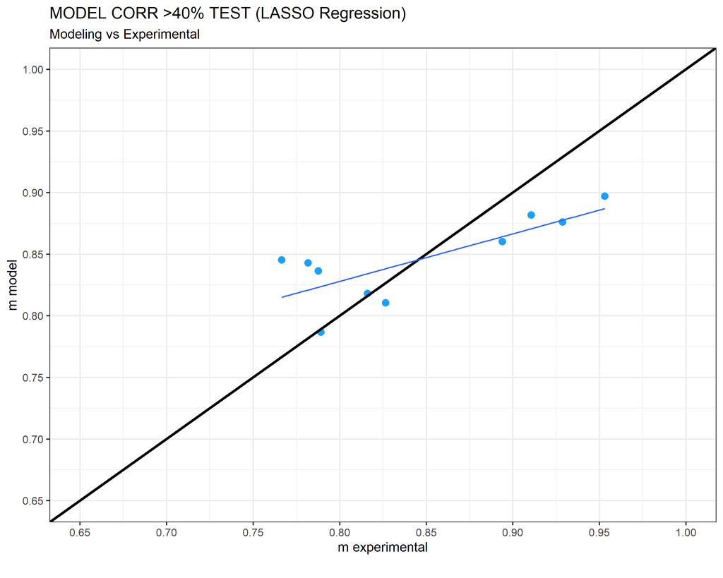